# Lab 05 - Data Wrangling

# Learning goals

- Use the `merge()` function to join two datasets.
- Deal with missings and impute data.
- Identify relevant observations using `quantile()`.
- Practice your GitHub skills.

# Lab description

For this lab we will be dealing with the meteorological dataset `met`. In this case, we will use `data.table` to answer some questions regarding the `met` dataset, while at the same time practice your Git+GitHub skills for this project.

This markdown document should be rendered using `github_document` document.

# Part 1: Setup a Git project and the GitHub repository

1. Go to wherever you are planning to store the data on your computer, and create a folder for this project
2. In that folder, save [this template](https://github.com/JSC370/JSC370-2025/blob/main/labs/lab05/lab05-wrangling-gam.Rmd) as “README.Rmd”. This will be the markdown file where all the magic will happen.
3. Go to your GitHub account and create a new repository of the same name that your local folder has, e.g., “JSC370-labs”.
4. Initialize the Git project, add the “README.Rmd” file, and make your first commit.
5. Add the repo you just created on GitHub.com to the list of remotes, and push your commit to origin while setting the upstream.

Most of the steps can be done using command line:

```bash
# Step 1
cd ~/Documents
mkdir JSC370-labs
cd JSC370-labs

# Step 2
wget https://raw.githubusercontent.com/JSC370/jsc370-2023/main/labs/lab05/lab05-wrangling-gam.Rmd
mv lab05-wrangling-gam.Rmd README.Rmd
# if wget is not available,
curl https://raw.githubusercontent.com/JSC370/jsc370-2023/main/labs/lab05/lab05-wrangling-gam.Rmd --output README.Rmd

# Step 3
# Happens on github

# Step 4
git init
git add README.Rmd
git commit -m "First commit"

# Step 5
git remote add origin git@github.com:[username]/JSC370-labs
git push -u origin master
```

You can also complete the steps in R (replace with your paths/username when needed)

```r
# Step 1
setwd("~/Documents")
dir.create("JSC370-labs")
setwd("JSC370-labs")

# Step 2
download.file(
  "https://raw.githubusercontent.com/JSC370/jsc370-2023/main/labs/lab05/lab05-wrangling-gam.Rmd",
  destfile = "README.Rmd"
  )

# Step 3: Happens on Github

# Step 4
system("git init && git add README.Rmd")
system('git commit -m "First commit"')

# Step 5
system("git remote add origin git@github.com:[username]/JSC370-labs")
system("git push -u origin master")
```

Once you are done setting up the project, you can now start working with the MET data.

## Setup in R

1. Load the `data.table` (and the `dtplyr` and `dplyr` packages).
2. Load the met data from https://raw.githubusercontent.com/JSC370/JSC370-2024/main/data/met_all_2023.gz, and also the station data. For the latter, you can use the code we used during lecture to pre-process the stations data:

```r
# Libraries
#install.packages("data.table")
#install.packages("kableExtra")
library(data.table)
library(leaflet)
library(dtplyr)
library(dplyr)
library(mgcv)
```

```r
library(ggplot2)
library(kableExtra)
library(tidyr)
# Download the data
stations <- fread("ftp://ftp.ncdc.noaa.gov/pub/data/noaa/isd-history.csv")
stations[, USAF := as.integer(USAF)]
# Dealing with NAs and 999999
stations[, USAF   := fifelse(USAF == 999999, NA_integer_, USAF)]
stations[, CTRY   := fifelse(CTRY == "", NA_character_, CTRY)]
stations[, STATE  := fifelse(STATE == "", NA_character_, STATE)]

# Selecting the three relevant columns, and keeping unique records
stations <- unique(stations[, list(USAF, CTRY, STATE)])

# Dropping NAs
stations <- stations[!is.na(USAF)]

# Removing duplicates
stations[, n := 1:.N, by = .(USAF)]
stations <- stations[n == 1,][, n := NULL]

# Read in the met data
met <- data.table::fread("met_all.gz")
```

3. Merge the data as we did during the lecture. Use the `merge()` code and you can also try the tidy way with `left_join()`

```r
met <- merge(
  x = met,
  y = stations,
  all.x = TRUE, all.y = FALSE,
  by.x = "USAFID", by.y = "USAF"
)

# OR

#met <- left_join(
#  x = met, y = stations,
#  by = c("USFID" = "USAF")
#)
```

## Question 1: Representative station for the US

Across all weather stations, what stations have the median values of temperature, wind speed, and atmospheric pressure? Using the `quantile()` function, identify these three stations. Do they coincide?

```r
medians <- met[, .(
  temp_50 = quantile(temp, probs = .5, na.rm = TRUE),
  wind.sp_50 = quantile(wind.sp, probs = .5, na.rm = TRUE),
  atm.press_50 = quantile(atm.press, probs = .5, na.rm = TRUE)
)]
medians
```

```
##    temp_50 wind.sp_50 atm.press_50
##      <num>      <num>        <num>
## 1:    23.5        2.1       1014.1
```

```r
station_med <- met[, .(
  temp = quantile(temp, probs = .5, na.rm = TRUE),
  wind.sp = quantile(wind.sp, probs = .5, na.rm = TRUE),
  atm.press = quantile(atm.press, probs = .5, na.rm = TRUE),
  lat = lat,
  lon = lon
), by = .(USAFID, STATE)]
head(station_med[order(station_med$USAFID)])
```

```
##    USAFID  STATE  temp wind.sp atm.press   lat      lon
##     <int> <char> <num>   <num>     <num> <num>    <num>
## 1: 690150     CA  32.8     3.1    1010.5  34.3 -116.166
## 2: 690150     CA  32.8     3.1    1010.5  34.3 -116.166
## 3: 690150     CA  32.8     3.1    1010.5  34.3 -116.166
## 4: 690150     CA  32.8     3.1    1010.5  34.3 -116.166
## 5: 690150     CA  32.8     3.1    1010.5  34.3 -116.166
## 6: 690150     CA  32.8     3.1    1010.5  34.3 -116.166
```

```r
station_med[, temp_dist := abs(temp - medians$temp_50)]
median_temp_station <- station_med[temp_dist == 0]
median_temp_station
```

```
##        USAFID  STATE  temp wind.sp atm.press    lat     lon temp_dist
##         <int> <char> <num>   <num>     <num>  <num>   <num>     <num>
##     1: 720501     VA  23.5     1.5        NA 37.850 -76.883         0
##     2: 720501     VA  23.5     1.5        NA 37.850 -76.883         0
##     3: 720501     VA  23.5     1.5        NA 37.850 -76.883         0
##     4: 720501     VA  23.5     1.5        NA 37.850 -76.883         0
##     5: 720501     VA  23.5     1.5        NA 37.850 -76.883         0
##    ---
## 14587: 725564     NE  23.5     2.6        NA 41.449 -96.520         0
## 14588: 725564     NE  23.5     2.6        NA 41.449 -96.520         0
## 14589: 725564     NE  23.5     2.6        NA 41.449 -96.520         0
## 14590: 725564     NE  23.5     2.6        NA 41.449 -96.520         0
## 14591: 725564     NE  23.5     2.6        NA 41.449 -96.520         0
```

```r
station_med[, wind.sp_dist := abs(wind.sp - medians$wind.sp_50)]
median_wind.sp_station <- station_med[wind.sp_dist == 0]
median_wind.sp_station
```

```
##         USAFID  STATE  temp wind.sp atm.press    lat      lon temp_dist
##          <int> <char> <num>   <num>     <num>  <num>    <num>     <num>
##      1: 720110     TX  31.0     2.1        NA 30.784  -98.662       7.5
##      2: 720110     TX  31.0     2.1        NA 30.784  -98.662       7.5
##      3: 720110     TX  31.0     2.1        NA 30.784  -98.662       7.5
##      4: 720110     TX  31.0     2.1        NA 30.784  -98.662       7.5
##      5: 720110     TX  31.0     2.1        NA 30.784  -98.662       7.5
##     ---
## 534371: 726813     ID  22.8     2.1   1011.75 43.650 -116.633       0.7
## 534372: 726813     ID  22.8     2.1   1011.75 43.650 -116.633       0.7
## 534373: 726813     ID  22.8     2.1   1011.75 43.650 -116.633       0.7
## 534374: 726813     ID  22.8     2.1   1011.75 43.642 -116.636       0.7
## 534375: 726813     ID  22.8     2.1   1011.75 43.642 -116.636       0.7
##         wind.sp_dist
##                <num>
##      1:            0
##      2:            0
##      3:            0
##      4:            0
##      5:            0
##     ---
## 534371:            0
## 534372:            0
## 534373:            0
## 534374:            0
## 534375:            0
```

```r
station_med[, atm.press_dist := abs(atm.press - medians$atm.press_50)]
median_atm.press_station <- station_med[atm.press_dist == 0]
median_atm.press_station
```

```
##        USAFID  STATE  temp wind.sp atm.press    lat     lon temp_dist
##         <int> <char> <num>   <num>     <num>  <num>   <num>     <num>
##     1: 722420     TX    30     4.6    1014.1 29.273 -94.859       6.5
##     2: 722420     TX    30     4.6    1014.1 29.273 -94.859       6.5
##     3: 722420     TX    30     4.6    1014.1 29.273 -94.859       6.5
##     4: 722420     TX    30     4.6    1014.1 29.273 -94.859       6.5
##     5: 722420     TX    30     4.6    1014.1 29.273 -94.859       6.5
##    ---
## 10732: 726590     SD    20     3.1    1014.1 45.443 -98.413       3.5
## 10733: 726590     SD    20     3.1    1014.1 45.443 -98.413       3.5
## 10734: 726590     SD    20     3.1    1014.1 45.443 -98.413       3.5
## 10735: 726590     SD    20     3.1    1014.1 45.443 -98.413       3.5
## 10736: 726590     SD    20     3.1    1014.1 45.443 -98.413       3.5
##        wind.sp_dist atm.press_dist
##               <num>          <num>
##     1:          2.5              0
##     2:          2.5              0
##     3:          2.5              0
##     4:          2.5              0
##     5:          2.5              0
##    ---
## 10732:          1.0              0
## 10733:          1.0              0
## 10734:          1.0              0
## 10735:          1.0              0
## 10736:          1.0              0
```

Knit the document, commit your changes, and save it on GitHub. Don’t forget to add `README.md` to the tree, the first time you render it.

## Question 2: Representative station per state

Just like the previous question, you are asked to identify what is the most representative, the median, station per state. This time, instead of looking at one variable at a time, look at the euclidean distance. If multiple stations show in the median, select the one located at the lowest latitude.

```r
station_med[, temp_50 := quantile(temp, probs = .5, na.rm = TRUE), by = STATE]
station_med[, wind.sp_50 := quantile(wind.sp, probs = .5, na.rm = TRUE), by = STATE]
station_med[, eudist := sqrt((temp - temp_50)^2 + (wind.sp - wind.sp_50)^2)]


id_station <- station_med[, .SD[which.min(eudist)], by = STATE]

id_station <- merge(
  x = id_station, y = stations,
  by.x = "USAFID", by.y = "USAF",
  all.x = TRUE, all.y = FALSE
)
id_station
```

```
## Key: <USAFID>
##     USAFID STATE.x  temp wind.sp atm.press    lat      lon temp_dist
##      <int>  <char> <num>   <num>     <num>  <num>    <num>     <num>
##  1: 720202      OR  17.0     1.5        NA 45.417 -123.817       6.5
##  2: 720278      VA  23.4     1.5        NA 36.687  -77.483       0.1
##  3: 720284      MI  20.8     2.1        NA 42.574  -84.811       2.7
##  4: 720301      GA  25.7     1.5        NA 32.646  -81.596       2.2
##  5: 720388      WA  18.0     0.0        NA 47.104 -122.287       5.5
##  6: 720456      KY  23.0     2.1        NA 38.067  -83.983       0.5
##  7: 720492      VT  18.2     1.5        NA 44.567  -72.017       5.3
##  8: 720521      WY  18.0     3.1        NA 41.444 -106.827       5.5
##  9: 720532      CO  19.8     2.6        NA 38.533 -106.050       3.7
## 10: 720541      MS  25.0     1.5        NA 34.383  -89.550       1.5
## 11: 720545      CT  22.0     2.1        NA 41.384  -72.506       1.5
## 12: 720596      SC  25.0     1.5        NA 34.300  -81.633       1.5
```

[output cut: 88 more lines]

Knit the doc and save it on GitHub.

## Question 3: In the middle?

For each state, identify what is the station that is closest to the mid-point of the state. Combining these with the stations you identified in the previous question, use `leaflet()` to visualize all ~100 points in the same figure, applying different colors for those identified in this question.

```r
# 1. Get the mid point of the state
mid_point <- met[, .(
  lon_50 = quantile(lon, probs = .5, na.rm = TRUE),
  lat_50 = quantile(lat, probs = .5, na.rm = TRUE)
), by = STATE]
mid_point
```

```
##      STATE   lon_50 lat_50
##     <char>    <num>  <num>
##  1:     CA -120.448 36.780
##  2:     TX  -97.691 31.178
##  3:     MI  -84.688 43.067
##  4:     SC  -80.634 34.181
##  5:     IL  -88.751 40.520
##  6:     MO  -93.183 38.583
##  7:     AR  -92.767 35.333
##  8:     OR -123.364 42.600
##  9:     WA -122.416 47.104
## 10:     GA  -83.270 32.564
## 11:     MN  -94.382 45.097
## 12:     AL  -86.557 32.915
## 13:     IN  -86.296 40.711
```

[output cut: 36 more lines]

```r
# 2. Calculate euclidean distance for lon and lat
mid <- merge(
  x = met, y = mid_point,
  by = "STATE"
)
mid[, mid_eudist := sqrt((lon - lon_50)^2 + (lat - lat_50)^2)]
# 3. Fin the closest station to mid-point of state
mid_station <- mid[, .SD[which.min(mid_eudist)], by = STATE]


leaflet() |>
  addProviderTiles("CartoDB.Positron") |>
  addCircles(
    data = mid_station,
    lat = ~lat, lng = ~lon, popup = "geographic mid station",
    opacity = 1, fillOpacity = 1, radius = 400, color = "blue"
  ) |>
  addCircles(
    data = id_station,
    lat = ~lat, lng = ~lon, popup = "eudist mid station",
    opacity = 1, fillOpacity = 1, radius = 400, color = "magenta"
  )
```

[interactive chart not shown]

Knit the doc and save it on GitHub.

## Question 4: Means of means

Using the `quantile()` function, generate a summary table that shows the number of states included, average temperature, wind-speed, and atmospheric pressure by the variable “average temperature level,” which you’ll need to create.

Start by computing the states’ average temperature. Use that measurement to classify them according to the following criteria:

- low: temp < 20
- Mid: temp >= 20 and temp < 25
- High: temp >= 25

```r
summary_table <- met |>
  group_by(STATE) |>
  summarize(
    total_records = n(),
    n_stations = n_distinct(USAFID),
    n_na = sum(is.na(temp) | is.na(wind.sp) | is.na(atm.press)),
    temp_mean = mean(temp, na.rm = TRUE),
    wind.sp_mean = mean(wind.sp, na.rm = TRUE),
    atm.press_mean = mean(atm.press, na.rm = TRUE),
    ) |>
  mutate(avg_temp_level = case_when(
    temp_mean < 20 ~ "low",
    temp_mean >= 20 & temp_mean < 25 ~ "mid",
    temp_mean >= 25 ~ "high"
  )) |>
  pivot_wider(names_from = avg_temp_level, values_from = temp_mean)
summary_table
```

```
## # A tibble: 48 × 9
##    STATE total_records n_stations  n_na wind.sp_mean atm.press_mean  high   mid
##    <chr>         <int>      <int> <int>        <dbl>          <dbl> <dbl> <dbl>
##  1 AL            44743         32 24171         1.57          1016.  26.2  NA
##  2 AR            34829         33 14634         1.84          1015.  26.2  NA
##  3 AZ            34150         32 17736         2.98          1011.  28.8  NA
##  4 CA           109392        101 50075         2.61          1013.  NA    22.4
##  5 CO            78843         54 56603         3.08          1014.  NA    NA
##  6 CT            11767         10  4872         2.19          1015.  NA    22.3
##  7 DE             3231          3   731         2.76          1015.  NA    24.6
##  8 FL            80933         64 44827         2.50          1015.  27.5  NA
##  9 GA            89241         52 71462         1.51          1015.  26.5  NA
## 10 IA           107995         58 95721         2.57          1015.  NA    21.3
## # ℹ 38 more rows
## # ℹ 1 more variable: low <dbl>
```

Once you are done with that, you can compute the following:

- Number of entries (records),
- Number of NA entries,
- Number of stations,
- Number of states included, and
- Mean temperature, wind-speed, and atmospheric pressure.

All by the levels described before.

```r
# Create table to present the data
kable(summary_table, booktabs = TRUE) |>
  kable_styling(font_size = 10) |>
  kable_paper("hover", full_width = F)
```

| STATE | total_records | n_stations | n_na | wind.sp_mean | atm.press_mean | high | mid | low |
| --- | --- | --- | --- | --- | --- | --- | --- | --- |
| AL | 44743 | 32 | 24171 | 1.566381 | 1016.148 | 26.19799 | NA | NA |
| AR | 34829 | 33 | 14634 | 1.836963 | 1014.551 | 26.20697 | NA | NA |
| AZ | 34150 | 32 | 17736 | 2.984547 | 1010.771 | 28.80596 | NA | NA |
| CA | 109392 | 101 | 50075 | 2.614120 | 1012.640 | NA | 22.36199 | NA |
| CO | 78843 | 54 | 56603 | 3.075255 | 1013.725 | NA | NA | 19.54725 |
| CT | 11767 | 10 | 4872 | 2.194895 | 1015.036 | NA | 22.25797 | NA |
| DE | 3231 | 3 | 731 | 2.762484 | 1015.058 | NA | 24.58116 | NA |
| FL | 80933 | 64 | 44827 | 2.501976 | 1015.242 | 27.53747 | NA | NA |
| GA | 89241 | 52 | 71462 | 1.509138 | 1015.168 | 26.53857 | NA | NA |
| IA | 107995 | 58 | 95721 | 2.568719 | 1015.210 | NA | 21.27773 | NA |
| ID | 16005 | 15 | 8403 | 2.380664 | 1013.222 | NA | 20.69554 | NA |
| IL | 73792 | 44 | 58790 | 2.171944 | 1014.215 | NA | 22.41005 | NA |
| IN | 38489 | 28 | 26458 | 2.260783 | 1015.035 | NA | 21.76562 | NA |
| KS | 40707 | 32 | 19386 | 3.729569 | 1013.360 | NA | 24.25538 | NA |
| KY | 30482 | 20 | 20821 | 1.788035 | 1015.301 | NA | 23.87157 | NA |
| LA | 60958 | 40 | 46739 | 1.724747 | 1014.591 | 27.97441 | NA | NA |
| MA | 20823 | 18 | 8606 | 2.699620 | 1014.755 | NA | 21.47484 | NA |
| MD | 21323 | 15 | 16503 | 1.855838 | 1015.285 | NA | 24.55218 | NA |
| ME | 12850 | 12 | 3778 | 2.133954 | 1014.362 | NA | NA | 18.79902 |
| MI | 119490 | 61 | 97042 | 2.215030 | 1014.853 | NA | 20.19981 | NA |
| MN | 120067 | 54 | 110369 | 2.427195 | 1014.965 | NA | NA | 19.35621 |
| MO | 36229 | 29 | 19639 | 2.379529 | 1014.616 | NA | 23.87039 | NA |
| MS | 33598 | 22 | 25111 | 1.477365 | 1014.995 | 26.41324 | NA | NA |
| MT | 7654 | 7 | 3034 | 3.426447 | 1014.095 | NA | NA | 18.16680 |
| NC | 100807 | 60 | 79239 | 1.634159 | 1015.612 | NA | 24.37801 | NA |
| ND | 39207 | 18 | 39207 | 3.869228 | NaN | NA | NA | 18.37173 |
| NE | 65209 | 39 | 49432 | 3.138987 | 1014.254 | NA | 22.10408 | NA |
| NH | 10862 | 10 | 3785 | 2.192529 | 1014.635 | NA | NA | 18.24715 |
| NJ | 16954 | 15 | 7402 | 1.884296 | 1014.791 | NA | 23.34497 | NA |
| NM | 37106 | 27 | 24857 | 3.477918 | 1011.992 | NA | 24.47771 | NA |
| NV | 18914 | 16 | 9802 | 2.999347 | 1011.621 | 26.04296 | NA | NA |
| NY | 34164 | 30 | 13546 | 2.320394 | 1015.015 | NA | 20.12499 | NA |
| OH | 51853 | 38 | 30911 | 2.423660 | 1015.315 | NA | 21.83450 | NA |
| OK | 80623 | 49 | 65970 | 3.231212 | 1012.610 | 27.40891 | NA | NA |
| OR | 10484 | 8 | 5834 | 2.094975 | 1015.112 | NA | NA | 18.68974 |
| PA | 47541 | 35 | 25548 | 1.812037 | 1015.614 | NA | 21.61523 | NA |
| RI | 4879 | 5 | 1791 | 2.728330 | 1013.606 | NA | 22.32827 | NA |
| SC | 63770 | 38 | 52858 | 1.696787 | 1015.335 | 25.87440 | NA | NA |
| SD | 26339 | 21 | 11914 | 3.774762 | 1014.389 | NA | 20.03650 | NA |
| TN | 21950 | 16 | 12987 | 1.519564 | 1014.448 | NA | 24.78164 | NA |
| TX | 248410 | 161 | 191916 | 3.190673 | 1012.285 | 29.59743 | NA | NA |
| UT | 20957 | 16 | 10470 | 4.402966 | 1012.005 | 25.82056 | NA | NA |
| VA | 83500 | 49 | 66903 | 1.696749 | 1015.235 | NA | 23.88116 | NA |
| VT | 14883 | 10 | 10187 | 1.671583 | 1014.645 | NA | NA | 18.76708 |
| WA | 6731 | 3 | 6731 | 1.236213 | NaN | NA | NA | 19.11089 |
| WI | 97544 | 57 | 81745 | 2.038866 | 1014.940 | NA | NA | 18.57907 |
| WV | 15396 | 12 | 7423 | 1.655494 | 1015.725 | NA | 21.74214 | NA |
| WY | 31669 | 26 | 17359 | 3.833987 | 1013.939 | NA | NA | 18.60170 |

Knit the document, commit your changes, and push them to GitHub.

## Question 5: Advanced Regression

Let’s practice running regression models with smooth functions on X. We need the `mgcv` package and `gam()` function to do this.

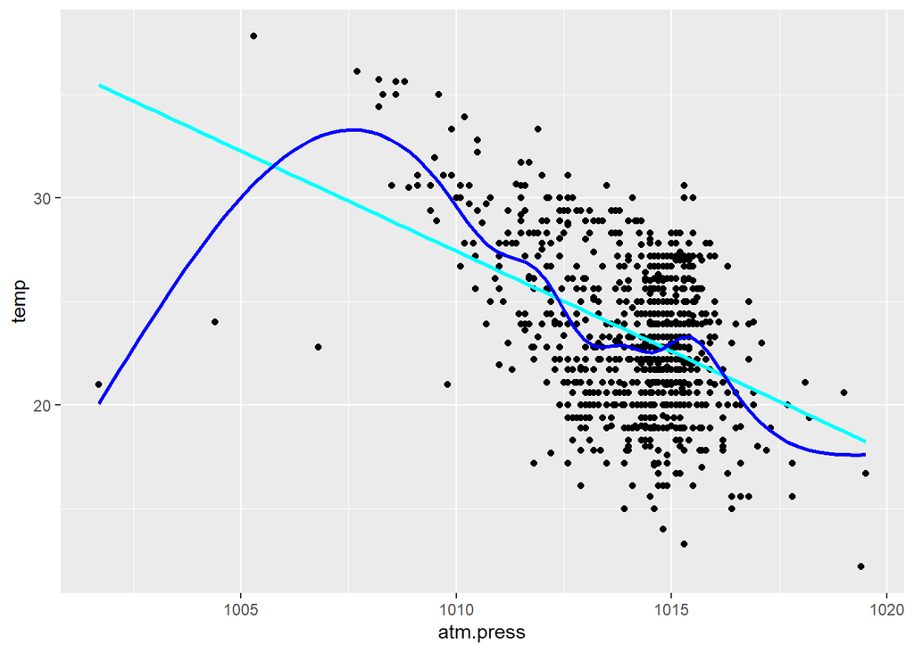

```r
station_med_lt <- lazy_dt(station_med)
station_med_lt <- station_med_lt |>
  filter(between(atm.press, 1000, 1020)) |>
  collect()

ggplot(station_med_lt, aes(x = atm.press, y = temp)) +
  geom_point() +
  geom_smooth(method = "lm", col  = "cyan") +
  geom_smooth(method = "gam", col = "blue")
```

```r
# linear with temp being y, atm press being x
lm_mod <- lm(temp ~ atm.press, data = station_med_lt)
summary(lm_mod)
```

```
##
## Call:
## lm(formula = temp ~ atm.press, data = station_med_lt)
##
## Residuals:
##      Min       1Q   Median       3Q      Max
## -14.4585  -2.3171   0.0992   2.6025   8.2858
##
## Coefficients:
##               Estimate Std. Error t value Pr(>|t|)
## (Intercept) 1003.59299    2.11990   473.4   <2e-16 ***
## atm.press     -0.96649    0.00209  -462.4   <2e-16 ***
## ---
## Signif. codes:  0 '***' 0.001 '**' 0.01 '*' 0.05 '.' 0.1 ' ' 1
##
## Residual standard error: 3.334 on 918387 degrees of freedom
## Multiple R-squared:  0.1888, Adjusted R-squared:  0.1888
## F-statistic: 2.138e+05 on 1 and 918387 DF,  p-value: < 2.2e-16
```

```r
# bs = "cr" cubic regression line, 20 degree of fredom
gam_mod <- gam(temp ~ s(atm.press, bs = "cr", k = 20), data = station_med_lt)
summary(gam_mod)
```

```
##
## Family: gaussian
## Link function: identity
##
## Formula:
## temp ~ s(atm.press, bs = "cr", k = 20)
##
## Parametric coefficients:
##              Estimate Std. Error t value Pr(>|t|)
## (Intercept) 23.402629   0.003265    7168   <2e-16 ***
## ---
## Signif. codes:  0 '***' 0.001 '**' 0.01 '*' 0.05 '.' 0.1 ' ' 1
##
## Approximate significance of smooth terms:
##              edf Ref.df     F p-value
## s(atm.press)  19     19 19331  <2e-16 ***
## ---
## Signif. codes:  0 '***' 0.001 '**' 0.01 '*' 0.05 '.' 0.1 ' ' 1
##
## R-sq.(adj) =  0.286   Deviance explained = 28.6%
## GCV = 9.7893  Scale est. = 9.7891    n = 918389
```

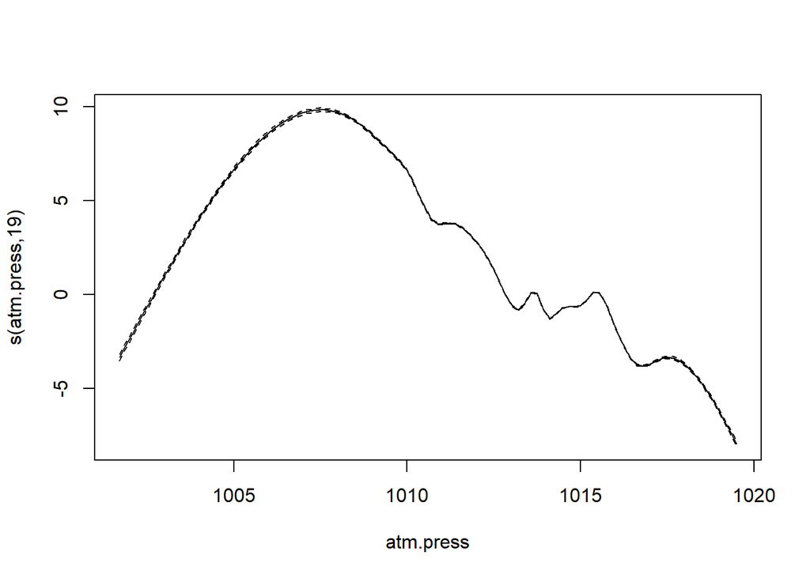

```r
plot(gam_mod)
```